# Analysis of Human Breast Cancer Cells

Kelsey Dang

10/29/2019

# 1. Exploratory Data Analysis

Use the read.csv() function to read the CSV (comma-separated values) file containing the data.

```r
wisc.df <- read.csv("WisconsinCancer.csv")
head(wisc.df)
```

```
##         id diagnosis radius_mean texture_mean perimeter_mean area_mean
## 1   842302         M       17.99        10.38         122.80    1001.0
## 2   842517         M       20.57        17.77         132.90    1326.0
## 3 84300903         M       19.69        21.25         130.00    1203.0
## 4 84348301         M       11.42        20.38          77.58     386.1
## 5 84358402         M       20.29        14.34         135.10    1297.0
## 6   843786         M       12.45        15.70          82.57     477.1
##   smoothness_mean compactness_mean concavity_mean concave.points_mean
## 1         0.11840          0.27760         0.3001             0.14710
## 2         0.08474          0.07864         0.0869             0.07017
## 3         0.10960          0.15990         0.1974             0.12790
## 4         0.14250          0.28390         0.2414             0.10520
## 5         0.10030          0.13280         0.1980             0.10430
## 6         0.12780          0.17000         0.1578             0.08089
##   symmetry_mean fractal_dimension_mean radius_se texture_se perimeter_se
```

[output cut: 41 more lines]

Now, see how many patients we have.

```r
nrow(wisc.df)
```

```
## [1] 569
```

How many patients are malignant?

```r
table(wisc.df$diagnosis)
```

```
##
##   B   M
## 357 212
```

Creating wisc.data

```r
# Convert the features of the data: wisc.data
wisc.data <- as.matrix(wisc.df[,3:32])

# Set the row names of wisc.data
row.names(wisc.data) <- wisc.df$id
head(wisc.data)
```

```
##          radius_mean texture_mean perimeter_mean area_mean smoothness_mean
## 842302         17.99        10.38         122.80    1001.0         0.11840
## 842517         20.57        17.77         132.90    1326.0         0.08474
## 84300903       19.69        21.25         130.00    1203.0         0.10960
## 84348301       11.42        20.38          77.58     386.1         0.14250
## 84358402       20.29        14.34         135.10    1297.0         0.10030
## 843786         12.45        15.70          82.57     477.1         0.12780
##          compactness_mean concavity_mean concave.points_mean symmetry_mean
## 842302            0.27760         0.3001             0.14710        0.2419
## 842517            0.07864         0.0869             0.07017        0.1812
## 84300903          0.15990         0.1974             0.12790        0.2069
## 84348301          0.28390         0.2414             0.10520        0.2597
## 84358402          0.13280         0.1980             0.10430        0.1809
## 843786            0.17000         0.1578             0.08089        0.2087
##          fractal_dimension_mean radius_se texture_se perimeter_se area_se
```

[output cut: 41 more lines]

Store the diagnosis for reference in the future as a separate vector

Setup a separate new vector called **diagnosis** that contains the data from the diagnosis column of the original dataset. We will use this later to check our results.

```r
# Create diagnosis vector for later
diagnosis <- wisc.df$diagnosis
```

## Exploratory Data Analysis

Q1. How many observations are in this dataset?

```r
nrow(wisc.df)
```

```
## [1] 569
```

Q2. How many of the observations have a malignant diagnosis?

```r
table(wisc.df$diagnosis)
```

```
##
##   B   M
## 357 212
```

Q3. How many variables/features in the data are suffixed with _mean?

```r
grep("_mean", colnames(wisc.df), value = TRUE)
```

```
##  [1] "radius_mean"            "texture_mean"
##  [3] "perimeter_mean"         "area_mean"
##  [5] "smoothness_mean"        "compactness_mean"
##  [7] "concavity_mean"         "concave.points_mean"
##  [9] "symmetry_mean"          "fractal_dimension_mean"
```

Use *length* to see the length

```r
length(grep("_mean", colnames(wisc.df), value = TRUE))
```

```
## [1] 10
```

# 2. Principal Component Analysis

## Performing PCA

The next step in your analysis is to perform principal component analysis (PCA) on wisc.data.

It is important to check if the data need to be scaled before performing PCA. Recall two common reasons for scaling data include:  
* The input variables use different units of measurement  
* The input variables have significantly different variances

Check the mean and standard deviation of the features (i.e. columns) of the wisc.data to determine if the data should be scaled. Use the colMeans() and apply() functions like you’ve done before.

```r
# Check column means and standard deviations
colMeans(wisc.data)
```

```
##             radius_mean            texture_mean          perimeter_mean
##            1.412729e+01            1.928965e+01            9.196903e+01
##               area_mean         smoothness_mean        compactness_mean
##            6.548891e+02            9.636028e-02            1.043410e-01
##          concavity_mean     concave.points_mean           symmetry_mean
##            8.879932e-02            4.891915e-02            1.811619e-01
##  fractal_dimension_mean               radius_se              texture_se
##            6.279761e-02            4.051721e-01            1.216853e+00
##            perimeter_se                 area_se           smoothness_se
##            2.866059e+00            4.033708e+01            7.040979e-03
##          compactness_se            concavity_se       concave.points_se
##            2.547814e-02            3.189372e-02            1.179614e-02
##             symmetry_se    fractal_dimension_se            radius_worst
##            2.054230e-02            3.794904e-03            1.626919e+01
##           texture_worst         perimeter_worst              area_worst
##            2.567722e+01            1.072612e+02            8.805831e+02
##        smoothness_worst       compactness_worst         concavity_worst
##            1.323686e-01            2.542650e-01            2.721885e-01
##    concave.points_worst          symmetry_worst fractal_dimension_worst
##            1.146062e-01            2.900756e-01            8.394582e-02
```

```r
apply(wisc.data,2,sd)
```

```
##             radius_mean            texture_mean          perimeter_mean
##            3.524049e+00            4.301036e+00            2.429898e+01
##               area_mean         smoothness_mean        compactness_mean
##            3.519141e+02            1.406413e-02            5.281276e-02
##          concavity_mean     concave.points_mean           symmetry_mean
##            7.971981e-02            3.880284e-02            2.741428e-02
##  fractal_dimension_mean               radius_se              texture_se
##            7.060363e-03            2.773127e-01            5.516484e-01
##            perimeter_se                 area_se           smoothness_se
##            2.021855e+00            4.549101e+01            3.002518e-03
##          compactness_se            concavity_se       concave.points_se
##            1.790818e-02            3.018606e-02            6.170285e-03
##             symmetry_se    fractal_dimension_se            radius_worst
##            8.266372e-03            2.646071e-03            4.833242e+00
##           texture_worst         perimeter_worst              area_worst
##            6.146258e+00            3.360254e+01            5.693570e+02
##        smoothness_worst       compactness_worst         concavity_worst
##            2.283243e-02            1.573365e-01            2.086243e-01
##    concave.points_worst          symmetry_worst fractal_dimension_worst
##            6.573234e-02            6.186747e-02            1.806127e-02
```

The function round() rounds the values in its first arg to the specified num of decimal places (default 0) or the second arg.

```r
round(apply(wisc.data, 2, sd), 3)
```

```
##             radius_mean            texture_mean          perimeter_mean
##                   3.524                   4.301                  24.299
##               area_mean         smoothness_mean        compactness_mean
##                 351.914                   0.014                   0.053
##          concavity_mean     concave.points_mean           symmetry_mean
##                   0.080                   0.039                   0.027
##  fractal_dimension_mean               radius_se              texture_se
##                   0.007                   0.277                   0.552
##            perimeter_se                 area_se           smoothness_se
##                   2.022                  45.491                   0.003
##          compactness_se            concavity_se       concave.points_se
##                   0.018                   0.030                   0.006
##             symmetry_se    fractal_dimension_se            radius_worst
##                   0.008                   0.003                   4.833
##           texture_worst         perimeter_worst              area_worst
##                   6.146                  33.603                 569.357
##        smoothness_worst       compactness_worst         concavity_worst
##                   0.023                   0.157                   0.209
##    concave.points_worst          symmetry_worst fractal_dimension_worst
##                   0.066                   0.062                   0.018
```

These values look very different so I will use **scale=TRUE** when I run PCA

```r
# Perform PCA on wisc.data by completing the following code
wisc.pr <- prcomp( wisc.data, scale = TRUE )
summary(wisc.pr)
```

```
## Importance of components:
##                           PC1    PC2     PC3     PC4     PC5     PC6
## Standard deviation     3.6444 2.3857 1.67867 1.40735 1.28403 1.09880
## Proportion of Variance 0.4427 0.1897 0.09393 0.06602 0.05496 0.04025
## Cumulative Proportion  0.4427 0.6324 0.72636 0.79239 0.84734 0.88759
##                            PC7     PC8    PC9    PC10   PC11    PC12
## Standard deviation     0.82172 0.69037 0.6457 0.59219 0.5421 0.51104
## Proportion of Variance 0.02251 0.01589 0.0139 0.01169 0.0098 0.00871
## Cumulative Proportion  0.91010 0.92598 0.9399 0.95157 0.9614 0.97007
##                           PC13    PC14    PC15    PC16    PC17    PC18
## Standard deviation     0.49128 0.39624 0.30681 0.28260 0.24372 0.22939
## Proportion of Variance 0.00805 0.00523 0.00314 0.00266 0.00198 0.00175
## Cumulative Proportion  0.97812 0.98335 0.98649 0.98915 0.99113 0.99288
##                           PC19    PC20   PC21    PC22    PC23   PC24
## Standard deviation     0.22244 0.17652 0.1731 0.16565 0.15602 0.1344
## Proportion of Variance 0.00165 0.00104 0.0010 0.00091 0.00081 0.0006
## Cumulative Proportion  0.99453 0.99557 0.9966 0.99749 0.99830 0.9989
##                           PC25    PC26    PC27    PC28    PC29    PC30
## Standard deviation     0.12442 0.09043 0.08307 0.03987 0.02736 0.01153
## Proportion of Variance 0.00052 0.00027 0.00023 0.00005 0.00002 0.00000
## Cumulative Proportion  0.99942 0.99969 0.99992 0.99997 1.00000 1.00000
```

PC1 v. PC2 plot

Color by cancer/non-cancer

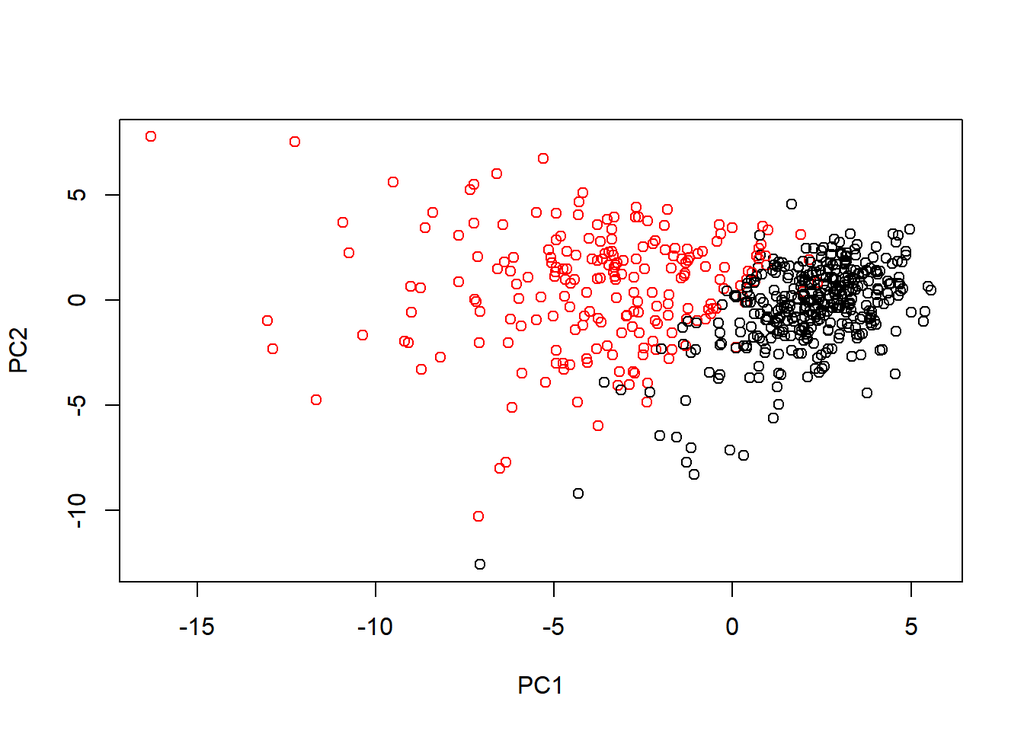

```r
# Scatter plot observations by components 1 and 2
plot(wisc.pr$x[,1], wisc.pr$x[,2], col=diagnosis, xlab = "PC1", ylab = "PC2")
```

You can see the split between cancerous and non-cancerous!

Q4. From your results, what proportion of the original variance is captured by the first principal components (PC1)?

```r
x <- summary(wisc.pr)
x$importance[,1]
```

```
##     Standard deviation Proportion of Variance  Cumulative Proportion
##               3.644394               0.442720               0.442720
```

```r
# By using importance can print out a specific col/row
# 0.4427
```

Q5. How many principal components (PCs) are required to describe at least 70% of the original variance in the data?

```r
which(x$importance[3,] > 0.7)[1]
```

```
## PC3
##   3
```

Q6. How many principal components (PCs) are required to describe at least 90% of the original variance in the data?

```r
which(x$importance[3,] > 0.9)[1]
```

```
## PC7
##   7
```

## Communicating PCA Results

In this section we will check your understanding of the PCA results, in particular the loadings and variance explained. The loadings, represented as vectors, explain the mapping from the original features to the principal components. The principal components are naturally ordered from the most variance explained to the least variance explained.

Q9. For the first principal component, what is the component of the loading vector (i.e. wisc.pr$rotation[,1]) for the feature concave.points_mean?

```r
wisc.pr$rotation["concave.points_mean",1]
```

```
## [1] -0.2608538
```

Q10. What is the minimum number of principal components required to explain 80% of the variance of the data?

```r
x <- summary(wisc.pr)
which(x$importance["Cumulative Proportion",] > 0.8)[1]
```

```
## PC5
##   5
```

# 3. Hierarchical Clustering

## Hierarchical clustering of case data

The goal of this section is to do hierarchical clustering of the observations. Recall from our last class that this type of clustering does not assume in advance the number of natural groups that exist in the data.

As part of the preparation for hierarchical clustering, the distance between all pairs of observations are computed. Furthermore, there are different ways to link clusters together, with single, complete, and average being the most common linkage methods.

Scale the wisc.data data and assign the result to data.scaled.

```r
# Scale the wisc.data data: data.scaled
data.scaled <- scale(wisc.data)
```

Calculate the Euclidean distances between all pairs of observations.

```r
data.dist <- dist(data.scaled)
```

Create a hierarchical clustering model using complete linkage

```r
wisc.hclust <- hclust(data.dist, method = "complete")
```

## Results of Hierarchical Clustering

Let’s use the hierarchical clustering model you just created to determine a height (or distance between clusters) where a certain number of clusters exists.

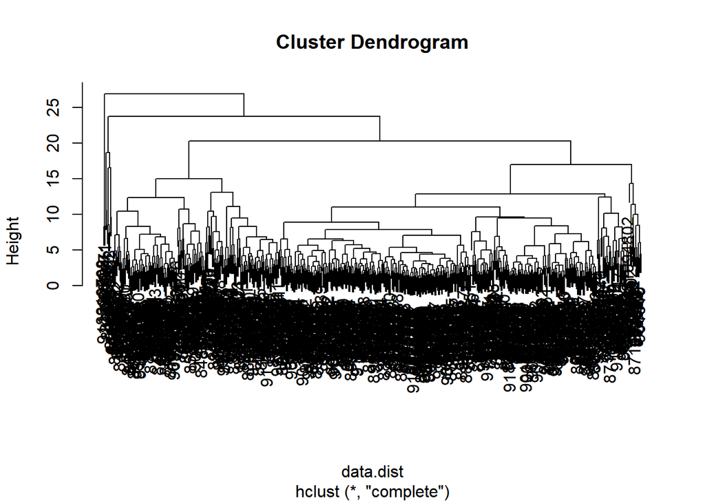

```r
plot(wisc.hclust)
abline(wisc.hclust, col="red", lty=2)
```

### Selecting number of clusters In this section, you will compare the outputs from your hierarchical clustering model to the actual diagnoses.  
Unsupervised learning - normally when performing unsupervised learning, a target variable (i.e. known answer or labels) aren’t available  
Supervised learning - when performing supervised learning, you’re trying to predict some target variable of interest and that target variable is available in the original data

Use cutree() to cut the tree so that it has 4 clusters. Assign the output to the variable wisc.hclust.clusters.

```r
wisc.hclust.clusters <- cutree(wisc.hclust, k=4)
table(wisc.hclust.clusters, diagnosis)
```

```
##                     diagnosis
## wisc.hclust.clusters   B   M
##                    1  12 165
##                    2   2   5
##                    3 343  40
##                    4   0   2
```

# 4. K-means Clustering

In this section, you will create a k-means clustering model on the Wisconsin breast cancer data and compare the results to the actual diagnoses and the results of your hierarchical clustering model. Take some time to see how each clustering model performs in terms of separating the two diagnoses and how the clustering models compare to each other.

Create a k-means model on wisc.data, assigning the result to wisc.km. Be sure to create 2 clusters, corresponding to the actual number of diagnosis. Also, remember to scale the data (with the scale() function and repeat the algorithm 20 times (by setting setting the value of the nstart argument appropriately). Running multiple times such as this will help to find a well performing model.

```r
wisc.km <- kmeans(scale(wisc.data), centers = 2, nstart = 20)
#head(wisc.km)
```

Use the table() function to compare the cluster membership of the k-means model (wisc.km$cluster) to the actual diagnoses contained in the diagnosis vector.

```r
table(wisc.km$cluster, diagnosis)
```

```
##    diagnosis
##       B   M
##   1 343  37
##   2  14 175
```

Use the table() function to compare the cluster membership of the k-means model (wisc.km$cluster) to your hierarchical clustering model from above (wisc.hclust.clusters). Recall the cluster membership of the hierarchical clustering model is contained in wisc.hclust.clusters object.

```r
table(wisc.hclust.clusters, wisc.km$cluster)
```

```
##
## wisc.hclust.clusters   1   2
##                    1  17 160
##                    2   0   7
##                    3 363  20
##                    4   0   2
```

# 5. Combining Methods

- Recall that the PCA model requires significantly fewer features to describe 70%, 80%, 95% of the variability of the data.
- In addition to normalizing data and potentially avoiding over-fitting, PCA also uncorrelates the variables, sometimes improving the performance of other modeling techniques

Let’s see if PCA improves or degrades the performance of heirarchical clustering.

Using the minimum num of principle components required to describe at LEAST 90% of the variability in the data, create a hierarchical clustering model with the linkage method = “ward.D2”. We use Ward’s criterion here because it is based on multidimensional variance like principal components analysis.

```r
wisc.pr.hclust <- hclust( dist(wisc.pr$x[, 1:7]) , method = "ward.D2")
```

```r
grps <- cutree(wisc.pr.hclust, k=2)
table(grps)
```

```
## grps
##   1   2
## 216 353
```

```r
table(grps, diagnosis)
```

```
##     diagnosis
## grps   B   M
##    1  28 188
##    2 329  24
```

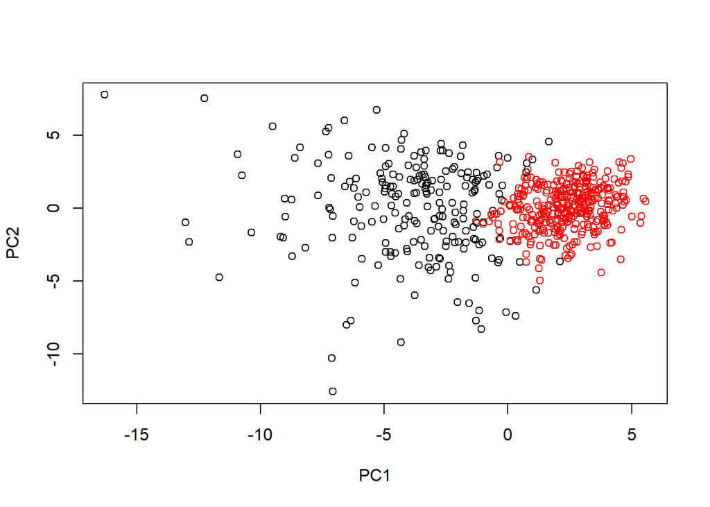

```r
plot(wisc.pr$x[,1:2], col=grps)
```

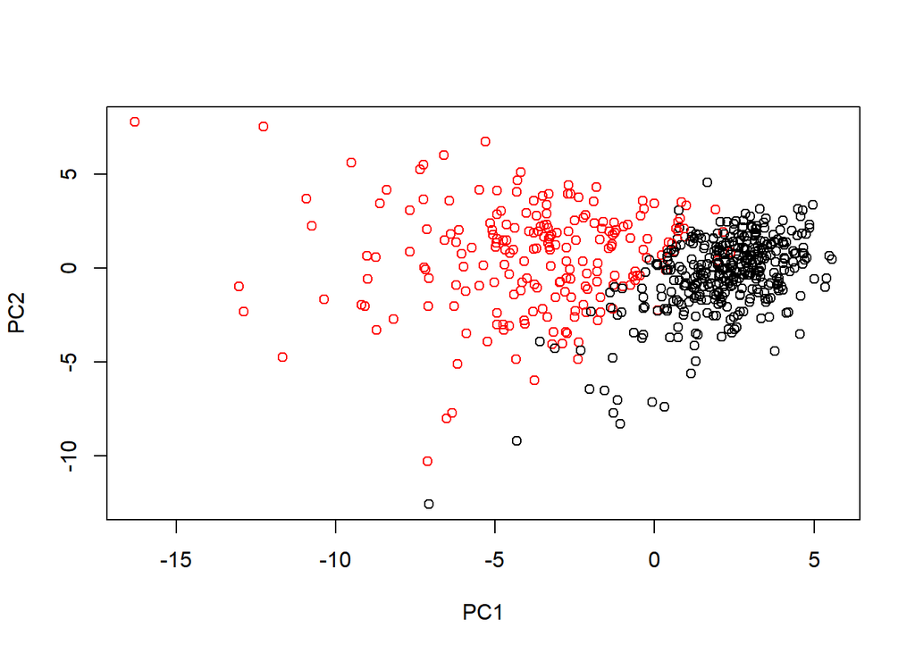

```r
plot(wisc.pr$x[,1:2], col=diagnosis)
```

**Note:** the color swap here as the hclust cluster1 is mostly “M” and cluster2 is mostly “B” as we saw from the results of calling table(). To match things up we can turn our groups into a factor and reorder the levels so cluster2 comes first.

```r
g <- as.factor(grps)
levels(g)
```

```
## [1] "1" "2"
```

```r
g <- relevel(g,2)
levels(g)
```

```
## [1] "2" "1"
```

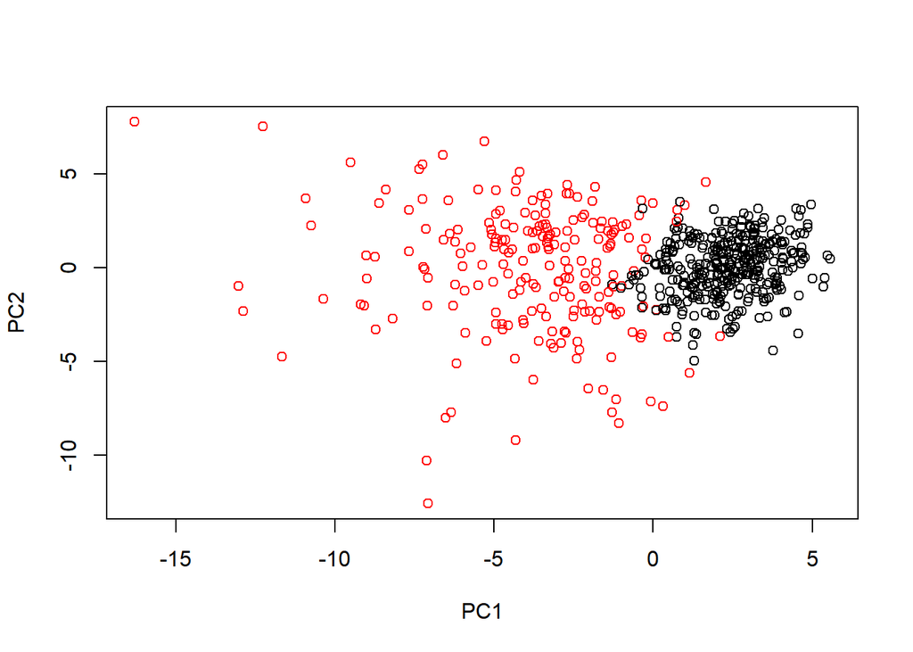

```r
# Plot using our re-ordered factor
plot(wisc.pr$x[,1:2], col=g)
```

# 6. Sensitivity/Specificity

- Sensitivity:
  - refers to a test’s ability to correctly detect ill patients who do have the condition.
  - In our example, sensitivity is the total number of samples in the cluster identified as predominately malignant (cancerous) divided by the total number of known malignant samples.
- Specificity:
  - relates to a test’s ability to correctly reject healthy patients without a condition.
  - In our example, specificity is the proportion of benign (not cancerous) samples in the cluster identified as predominantly benign that are known to be benign.

# 7. Prediction

We will use the **predict()** function that will take our PCA model from before and new cancer cell data and project that data onto our PCA space.

```r
#url <- "new_samples.csv"
url <- "https://tinyurl.com/new-samples-CSV"
new <- read.csv(url)
npc <- predict(wisc.pr, newdata=new)
npc
```

```
##            PC1       PC2        PC3        PC4       PC5        PC6
## [1,]  2.576616 -3.135913  1.3990492 -0.7631950  2.781648 -0.8150185
## [2,] -4.754928 -3.009033 -0.1660946 -0.6052952 -1.140698 -1.2189945
##             PC7        PC8       PC9       PC10      PC11      PC12
## [1,] -0.3959098 -0.2307350 0.1029569 -0.9272861 0.3411457  0.375921
## [2,]  0.8193031 -0.3307423 0.5281896 -0.4855301 0.7173233 -1.185917
##           PC13     PC14      PC15       PC16        PC17        PC18
## [1,] 0.1610764 1.187882 0.3216974 -0.1743616 -0.07875393 -0.11207028
## [2,] 0.5893856 0.303029 0.1299153  0.1448061 -0.40509706  0.06565549
##             PC19       PC20       PC21       PC22       PC23       PC24
## [1,] -0.08802955 -0.2495216  0.1228233 0.09358453 0.08347651  0.1223396
## [2,]  0.25591230 -0.4289500 -0.1224776 0.01732146 0.06316631 -0.2338618
##             PC25         PC26         PC27        PC28         PC29
## [1,]  0.02124121  0.078884581  0.220199544 -0.02946023 -0.015620933
## [2,] -0.20755948 -0.009833238 -0.001134152  0.09638361  0.002795349
##              PC30
## [1,]  0.005269029
## [2,] -0.019015820
```

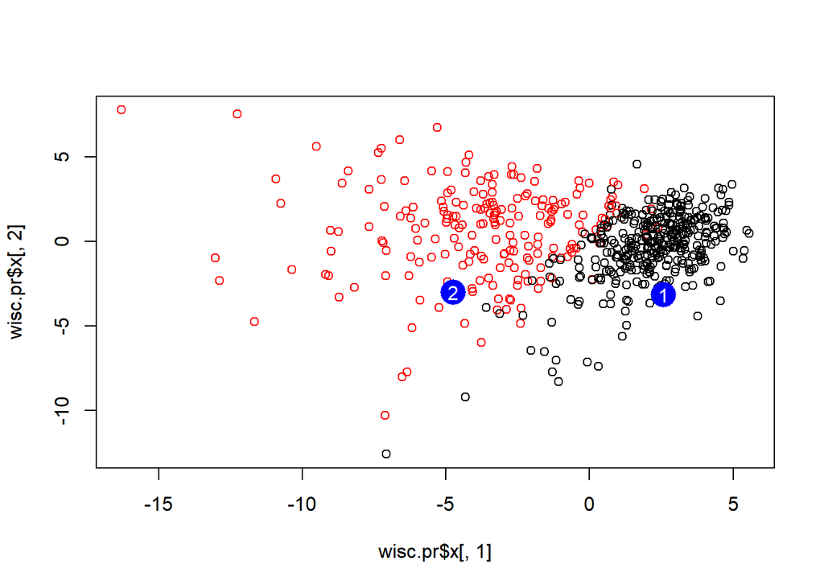

```r
plot(wisc.pr$x[,1], wisc.pr$x[,2], col=diagnosis)
points(npc[,1], npc[,2], col="blue", pch=16, cex=3)
text(npc[,1], npc[,2], c(1,2), col="white")
```

Q17. Which of these new patients should we prioritize for follow up based on your results? Patient 2